# Numerical Methods of Accelerator Physics

### Comparison with external phase focusing from RF

Compute the effective external RF field as a mean via the rf wave kick per circumference:

```python
E_rf = m.voltage / m.circumference * np.sin(
    -m.harmonic * slice_centres * 2 * np.pi / m.circumference + m.phi_s)
# E_rf = -np.gradient(U(slice_centres, m) / charge * c, slice_centres)
```

The external phase focusing by the rf wave and the space-charge field sum up:

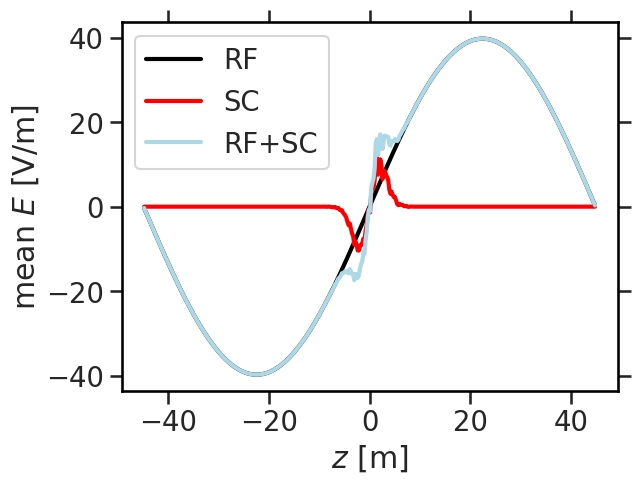

```python
plt.plot(slice_centres, E_rf, c='k', label='RF')
plt.plot(slice_centres, E_z, c='r', label='SC')
plt.plot(slice_centres, E_rf + E_z, c='lightblue', label='RF+SC')

plt.legend()
plt.xlabel('$z$ [m]')
plt.ylabel('mean $E$ [V/m]');
```

$\implies$ What happens to the net phase focusing which the bunch experiences? Will the RF bucket increase or rather shrink in momentum acceptance?

## Longitudinal Space Charge vs. Transition

Since the chosen flank (falling/rising) of the rf wave depends on the phase slippage (below/above transition), the effect of longitudinal space charge on phase focusing depends on classical vs. relativistic regime!

| **classical regime** | **relativistic regime** |
| --- | --- |
| $\eta < 0$ | $ \eta > 0$ |
| $\gamma < \gamma_\text{t}$ | $\gamma > \gamma_\text{t}$ |
| $\implies$ $\varphi_s$ on rising slope of $V(\varphi)$ | $\implies$ $\varphi_s$ on falling slope of $V(\varphi)$ |
| [$z(\varphi_s)$ on falling slope of $V(z)$] | [$z(\varphi_s)$ on rising slope of $V(z)$] |
| space charge **defocuses** | space charge **focuses** |

$\implies$ Choose $\gamma=7$. Are we above transition energy? Provide stable rf conditions and repeat the above computations! Can you confirm that space charge acts in the same way (focusing) as the rf wave now?

## Fate of a Perturbation?

Consider a (space-charge-) matched distribution in longitudinal phase space. Suppose a small perturbation in the line charge density, e.g. a trough in the bunch profile. The effect by the space-charge field:

$$E_z(z) = -\cfrac{g}{4\pi\epsilon_0\gamma^2}\,\cfrac{d\lambda}{dz}$$

1. **below transition:**
- particles speed up in regions where $\frac{d\lambda}{dz}<0$
- particles slow down in regions where $\frac{d\lambda}{dz}>0$

$\implies$ the trough will be filled with particles, the perturbation is **damped**

2. **above transition:** reverse situation!

$\implies$ the perturbation **grows**

**$\implies$ INSTABILITY!**

## Part III: Negative-Mass / Microwave Instability

## About the Microwave Instability

- instability typically develops above **intensity threshold**
- instability only appears **above transition**
- often observed as bunch length oscillations increasing on average, immediately after transition crossing $\implies$ **longitudinal emittance growth**
- emittance growth leads to larger synchrotron tune spread $\implies$ eventual **Landau damping of instability** (natural end of instability evolution)

[figure not shown]

images from [E. Shaposhnikova](https://cds.cern.ch/record/381423/files/sl-99-008.pdf) and [A. Lasheen](https://accelconf.web.cern.ch/ipac2021/papers/wepab243.pdf)

## Let's simulate it!

We implement the space-charge kick for the tracking:

```python
def space_charge_kick(z_n, deltap_n, machine, charge_per_mp=charge_per_mp, N_slices=N_slices, g=g):
    m = machine
    rfbucket_z_right = m.circumference / m.harmonic / 2
    rfbucket_z_left = -rfbucket_z_right

    # slicing
    slice_boundaries = np.linspace(rfbucket_z_left, rfbucket_z_right, N_slices + 1, endpoint=True)
    N_per_slice, _ = np.histogram(z_n, bins=slice_boundaries)
    # find slice index for each particle:
    slice_idx_per_mp = np.floor((z_n - slice_boundaries[0]) /
                                (slice_boundaries[1] - slice_boundaries[0])).astype(int)

    # get line charge density derivative
    lmbda = charge_per_mp * N_per_slice / np.diff(slice_boundaries)
    lmbda_prime = np.gradient(lmbda, slice_boundaries[:-1])

    # space-charge field per slice
    E_z = -g / (4 * np.pi * epsilon_0 * m.gamma_ref**2) * lmbda_prime

    # momentum update
    deltap_n1 = deltap_n - charge * E_z[slice_idx_per_mp] * m.circumference / (beta(m.gamma_ref) * c)
    return deltap_n1
```

The kicks which the particles receive look as follows:

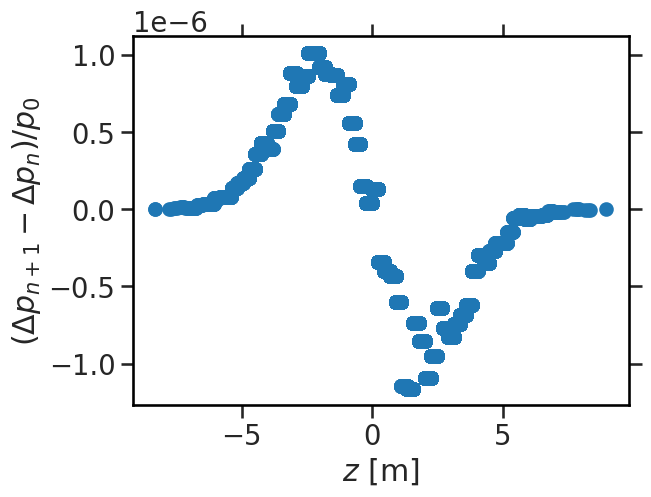

```python
plt.scatter(z, (space_charge_kick(z, deltap, m) - deltap) / m.p0())
plt.xlabel('$z$ [m]')
plt.ylabel('$(\Delta p_{n+1} - \Delta p_{n}) / p_0$');
```

We implement the one-turn tracking:

```python
def track_one_turn(z_n, deltap_n, machine, **kwargs):
    m = machine
    # half drift
    z_nhalf = z_n - m.eta(deltap_n) * deltap_n / m.p0() * m.circumference / 2
    # rf kick
    amplitude = charge * m.voltage / (beta(gamma(m.p0())) * c)
    phi = m.phi_s - m.harmonic * 2 * np.pi * z_nhalf / m.circumference

    m.update_gamma_ref()
    deltap_n1 = deltap_n + amplitude * (np.sin(phi) - np.sin(m.phi_s))
    # space-charge kick
    deltap_n1 = space_charge_kick(z, deltap_n1, m, **kwargs)
    # half drift
    z_n1 = z_nhalf - m.eta(deltap_n1) * deltap_n1 / m.p0() * m.circumference / 2
    return z_n1, deltap_n1
```